# Examine ND results by chain SStype

- Protein chains are partitioned into three classes by secondary structure content.
- Correlations with exp. fold rate vary by SStype and ND variant.
- Fold rate corrs should at least outperform N for the task of fold rate prediction, and outperform h for the purpose of estimating a resonable edge ordering.
- Slightly improved correlation for UZ when peak Es from ND variants are mixed by SStype and $p_e$ is adjusted by SStype.
- K correlation largely a factor of *AB* chains, which dominates the dataset.
- Results point to a need for a more subtle contact formation strategy in ND: context-sensitive at level of nodes or edges.

```python
import os
import numpy as np
import pandas as pd
from scipy.stats import pearsonr
from sklearn import linear_model
import matplotlib.pyplot as plt
import NDutils as nd # my lib
```

```python
NDVs = ['y', 'r', 'a', 'c', 'x', 'h']
```

- ND variants are arranged in LE/SE priority order in the sense that models towards the right respect the tenent of forming SE over LE more strictly, while models towards the left give more chances for LE to form before SE, with 'y' adopting this inversion of priority explicitly in its $p_e$.
- 'h' is distinct from the other ND variants in that edge ordering is strictly determined by sequence distance (increasing monotonically), while the other ND variants are stochastic processes.

## Uzunoglo

```python
dirname = "Uzunoglo"
fn = os.path.join(dirname, "UZ_foldtype.txt")
DF = pd.read_table(fn, sep=' ')
DF.head() # reserve DF for this purpose!
```

|  | pid | N | SRIM | LRIM | k_f | SStype |
| --- | --- | --- | --- | --- | --- | --- |
| 0 | 1afi | 72 | -7.50 | -6.25 | 0.26 | ab |
| 1 | 1aps | 98 | -9.41 | -6.97 | -0.64 | ab |
| 2 | 1ayi | 86 | -5.87 | -5.75 | 3.13 | a |
| 3 | 1bf4 | 63 | -5.77 | -5.43 | 3.02 | ab |
| 4 | 1c9o | 66 | -7.54 | -6.07 | 3.14 | b |

```python
UZ_PIDs = DF.pid.values
UZ_frates = DF.k_f.values
print(len(UZ_PIDs), np.ptp(UZ_frates))
UZ_SStypes = DF.SStype.values
```

```
52 5.96
```

### Defining SStype for chains

- The three chain fold types or chain *SStypes* are:
  - *A* for chains with predominantly $\alpha$ residues
    - number of $\alpha$ residues (nH) > 3, number of $\beta$ residues (nS) < 11, and nH/nS $\approx$ nH or >> 1;
  - *B* for chains with predominantly $\beta$ residues
    - nS > 10, nH < 4, and nH/nS $\approx$ 0.0;
  - *AB* otherwise.

```python
df = nd.count_HSTs("Uzunoglo", UZ_PIDs, UZ_SStypes)
print(df.dtypes)
df.sample(5)
```

```
H           int64
S           int64
T           int64
hsr       float64
SStype     object
dtype: object
```

|  | H | S | T | hsr | SStype |
| --- | --- | --- | --- | --- | --- |
| 2qjl | 29 | 33 | 37 | 0.878788 | ab |
| 1ayi | 50 | 0 | 36 | 50.000000 | a |
| 1e0m | 0 | 13 | 24 | 0.000000 | b |
| 1div_c | 34 | 37 | 22 | 0.918919 | ab |
| 1rlq | 0 | 22 | 34 | 0.000000 | b |

```python
da = df.query("SStype == 'a'")
print(len(da))
da
```

```
15
```

|  | H | S | T | hsr | SStype |
| --- | --- | --- | --- | --- | --- |
| 1ayi | 50 | 0 | 36 | 50.000000 | a |
| 1enh | 38 | 0 | 16 | 38.000000 | a |
| 1fex | 31 | 0 | 28 | 31.000000 | a |
| 1hrc | 43 | 2 | 59 | 21.500000 | a |
| 1idy | 33 | 0 | 21 | 33.000000 | a |
| 1imq | 46 | 0 | 40 | 46.000000 | a |
| 1lmb | 62 | 0 | 25 | 62.000000 | a |
| 1ryk | 45 | 0 | 24 | 45.000000 | a |
| 1ss1 | 43 | 0 | 17 | 43.000000 | a |
| 1w4e | 19 | 4 | 22 | 4.750000 | a |
| 1w4j | 23 | 3 | 25 | 7.666667 | a |
| 1yza | 70 | 0 | 36 | 70.000000 | a |
| 2abd | 52 | 0 | 34 | 52.000000 | a |
| 2bth | 22 | 2 | 21 | 11.000000 | a |
| 2pdd | 19 | 0 | 23 | 19.000000 | a |

```python
# reclassified 1o6x as 'ab', nH > 3
db = df.query("SStype == 'b'")
print(len(db))
db
```

```
17
```

|  | H | S | T | hsr | SStype |
| --- | --- | --- | --- | --- | --- |
| 1c9o | 3 | 41 | 22 | 0.073171 | b |
| 1csp | 3 | 37 | 27 | 0.081081 | b |
| 1e0l | 0 | 12 | 25 | 0.000000 | b |
| 1e0m | 0 | 13 | 24 | 0.000000 | b |
| 1fnf_9 | 0 | 49 | 39 | 0.000000 | b |
| 1g6p | 0 | 31 | 35 | 0.000000 | b |
| 1jo8 | 3 | 26 | 29 | 0.115385 | b |
| 1k9q | 0 | 13 | 27 | 0.000000 | b |
| 1m9s | 3 | 17 | 55 | 0.176471 | b |
| 1mjc | 3 | 34 | 32 | 0.088235 | b |
| 1psf | 0 | 21 | 48 | 0.000000 | b |
| 1rlq | 0 | 22 | 34 | 0.000000 | b |
| 1shf | 3 | 27 | 29 | 0.111111 | b |
| 1shg | 3 | 29 | 25 | 0.103448 | b |
| 1ten | 0 | 48 | 41 | 0.000000 | b |
| 1tit | 0 | 33 | 56 | 0.000000 | b |
| 3ait | 0 | 38 | 36 | 0.000000 | b |

```python
# reclassified 1g6p, 1m9s 'b'
dab = df.query("SStype == 'ab'")
print(len(dab))
dab
```

```
20
```

|  | H | S | T | hsr | SStype |
| --- | --- | --- | --- | --- | --- |
| 1afi | 21 | 21 | 30 | 1.000000 | ab |
| 1aps | 18 | 36 | 44 | 0.500000 | ab |
| 1bf4 | 15 | 33 | 15 | 0.454545 | ab |
| 1div_c | 34 | 37 | 22 | 0.918919 | ab |
| 1div_n | 26 | 13 | 18 | 2.000000 | ab |
| 1fkb | 11 | 43 | 53 | 0.255814 | ab |
| 1n88 | 22 | 27 | 47 | 0.814815 | ab |
| 1o6x | 25 | 16 | 40 | 1.562500 | ab |
| 1pgb | 14 | 24 | 18 | 0.583333 | ab |
| 1poh | 29 | 23 | 33 | 1.260870 | ab |
| 1rfa | 15 | 21 | 42 | 0.714286 | ab |
| 1ris | 28 | 47 | 22 | 0.595745 | ab |
| 1spr | 18 | 31 | 54 | 0.580645 | ab |
| 1ubq | 18 | 26 | 32 | 0.692308 | ab |
| 1urn | 31 | 24 | 41 | 1.291667 | ab |
| 2acy | 24 | 41 | 33 | 0.585366 | ab |
| 2ci2 | 14 | 18 | 33 | 0.777778 | ab |
| 2ptl | 12 | 25 | 25 | 0.480000 | ab |
| 2qjl | 29 | 33 | 37 | 0.878788 | ab |
| 2vik | 27 | 30 | 69 | 0.900000 | ab |

### Initial exploration of UZ DF

- There should be a sensible relationship between exp. fold rate with:
  - chain length *N*: longer chains (larger *N*) generally take longer to fold (smaller fold rate value). Scaled *N* is also examined: 1/2, 2/3.
  - chain *SStype*: *A* chains generally fold faster (larger fold rate value) than *B* chains.

```
Pearson correlation with exp. fold rate: chain-length N 1
All: [-0.4355  0.0013]
A: [-0.6721  0.0061]
AB: [-0.185   0.4349]
B: [-7.425e-01  6.000e-04]

Pearson correlation with exp. fold rate: chain-length N 0.5
All: [-0.4572  0.0007]
A: [-0.6842  0.0049]
AB: [-0.1988  0.4009]
B: [-7.502e-01  5.000e-04]

Pearson correlation with exp. fold rate: chain-length N 0.6666666666666666
All: [-0.4504  0.0008]
A: [-0.6807  0.0052]
AB: [-0.1944  0.4115]
B: [-7.479e-01  6.000e-04]
```

| SStype | n_rs | n_ps | n12_rs | n12_ps | n23_rs | n23_ps |
| --- | --- | --- | --- | --- | --- | --- |
| Z | -0.435466 | 0.001253 | -0.457243 | 0.000655 | -0.450355 | 0.000808 |
| A | -0.672115 | 0.006056 | -0.684221 | 0.004902 | -0.680697 | 0.005218 |
| AB | -0.185007 | 0.434873 | -0.198762 | 0.400861 | -0.194397 | 0.411493 |
| B | -0.742475 | 0.000641 | -0.750195 | 0.000523 | -0.747886 | 0.000556 |

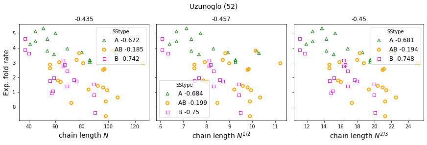

```python
n_dr = nd.frate_corrs_with_N_by_SStype(DF, "Uzunoglo (52)")
n_dr
```

### ND-hard (ndh)

- PRN0 edges are batch recreated in monotonically increasing sequence distance order.

```python
dirn = os.path.join("UZ_NDH", "hard")
```

```python
# example of a datafile
pid = "1aps"
fn = os.path.join(dirn, pid + "_bsd_hstats_h.out")
dh = pd.read_table(fn, sep=' ')
dh.head()
```

|  | bid | fe | fsc | sc_mje | num_sc | num_scle | num_nnsc | num_nnscle |
| --- | --- | --- | --- | --- | --- | --- | --- | --- |
| 0 | 2 | 0.137536 | 0.000000 | 0.00 | 0 | 0 | 0 | 0 |
| 1 | 3 | 0.237822 | 0.371257 | 71.70 | 62 | 0 | 96 | 0 |
| 2 | 4 | 0.295129 | 0.479042 | 101.00 | 80 | 0 | 119 | 0 |
| 3 | 5 | 0.340974 | 0.485030 | 180.40 | 81 | 0 | 151 | 0 |
| 4 | 6 | 0.368195 | 0.491018 | 226.07 | 82 | 0 | 168 | 0 |

```python
maxEs, argmaxEs, maxE_sds = nd.get_ndh_maxEs(dirn, UZ_PIDs)
h_df = DF.assign(maxE=maxEs, maxE_sd=maxE_sds)
h_df.head()
```

|  | pid | N | SRIM | LRIM | k_f | SStype | maxE | maxE_sd |
| --- | --- | --- | --- | --- | --- | --- | --- | --- |
| 0 | 1afi | 72 | -7.50 | -6.25 | 0.26 | ab | 372.23 | 13 |
| 1 | 1aps | 98 | -9.41 | -6.97 | -0.64 | ab | 462.15 | 27 |
| 2 | 1ayi | 86 | -5.87 | -5.75 | 3.13 | a | 213.28 | 10 |
| 3 | 1bf4 | 63 | -5.77 | -5.43 | 3.02 | ab | 95.47 | 9 |
| 4 | 1c9o | 66 | -7.54 | -6.07 | 3.14 | b | 109.78 | 10 |

```
maxE_sds: 12.73076923076923 5.299335454510013 4 31
maxE Pearson corr. with exp. fold rate: (-0.4445872304072675, 0.0009598432602786288)
```

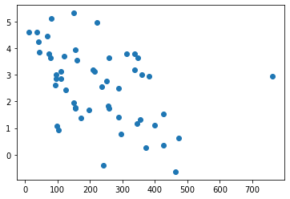

```python
print("maxE_sds:", np.mean(maxE_sds), np.std(maxE_sds, ddof=1),
      np.min(maxE_sds), np.max(maxE_sds))
# correlation maxEs with exp. fold rate
print("maxE Pearson corr. with exp. fold rate:", pearsonr(maxEs, UZ_frates))
# check for outliers
_ = plt.scatter(maxEs, UZ_frates)
```

```python
h_df.query("maxE > 700") # outlier
```

|  | pid | N | SRIM | LRIM | k_f | SStype | maxE | maxE_sd |
| --- | --- | --- | --- | --- | --- | --- | --- | --- |
| 50 | 2vik | 126 | -7.44 | -6.25 | 2.95 | ab | 762.08 | 21 |

```python
h_rs, h_ps = nd.analyze_maxE_by_SStype(h_df)
```

```
maxE_sd mean stdev
All: [12.7308  5.2993]
A: [10.6667  2.3503]
AB: [16.1    5.821]
B: [10.5882  4.6241]

Pearson correlation with exp. fold rate: maxE
All: [-0.4446  0.001 ]
A: [-0.5552  0.0317]
AB: [-0.326   0.1607]
B: [-0.555   0.0207]
```

- Compared with *A* and *B* chains, AB chains have larger maxE_sd on average.
  - maxE_sd marks the point where ND energy profile changes direction (increase to decrease).
  - A hint that perhaps LE need to appear earlier.
  - Corr. for AB is not significant (p > 0.05) because of the outlier.

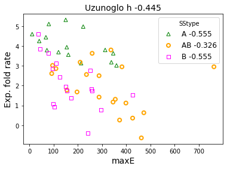

```python
fig, ax1 = plt.subplots()
ax = nd.plot_maxE_by_SStype(h_df, ax1, h_rs)
ax.set_title("Uzunoglo h " + str(np.round(h_rs[0], 3)), fontsize=14)
_ = ax.legend(title="SStype", fontsize=12)
```

```python
# excluding outlier
h1_df = h_df.query("pid != '2vik'") # ab
len(h1_df)
```

```
51
```

```python
h1_rs, h1_ps = nd.analyze_maxE_by_SStype(h1_df)
```

```
maxE_sd mean stdev
All: [12.5686  5.2202]
A: [10.6667  2.3503]
AB: [15.8421  5.862 ]
B: [10.5882  4.6241]

Pearson correlation with exp. fold rate: maxE
All: [-0.5417  0.    ]
A: [-0.5552  0.0317]
AB: [-0.6196  0.0047]
B: [-0.555   0.0207]
```

### ND variants (ndv): craxy

```python
dirn = os.path.join("UZ_ND3", "edv_a")
```

```python
peakEs, peakQs = nd.get_ndv_peakEs(dirn, UZ_PIDs, "stats", ndv='a')
a_df = DF.assign(peakE = peakEs)
a_rs, a_ps = nd.analyze_peakE_by_SStype(a_df, 'a')

peakEs, peakQs = nd.get_ndv_peakEs(dirn, UZ_PIDs, "stats", ndv='c')
c_df = DF.assign(peakE = peakEs)
c_rs, c_ps = nd.analyze_peakE_by_SStype(c_df, 'c')

peakEs, peakQs = nd.get_ndv_peakEs(dirn, UZ_PIDs, "stats", ndv='x')
x_df = DF.assign(peakE = peakEs)
x_rs, x_ps = nd.analyze_peakE_by_SStype(x_df, 'x')

peakEs, peakQs = nd.get_ndv_peakEs(dirn, UZ_PIDs, "stats", ndv='r')
r_df = DF.assign(peakE = peakEs)
r_rs, r_ps = nd.analyze_peakE_by_SStype(r_df, 'r')

peakEs, peakQs = nd.get_ndv_peakEs(dirn, UZ_PIDs, "stats", ndv='y')
y_df = DF.assign(peakE = peakEs)
y_rs, y_ps = nd.analyze_peakE_by_SStype(y_df, 'y')
```

```
Pearson correlation with exp. fold rate: a
All: [-0.7267  0.    ]
A: [-0.4121  0.1269]
AB: [-0.6481  0.002 ]
B: [-0.5744  0.0159]

Pearson correlation with exp. fold rate: c
All: [-0.7106  0.    ]
A: [-0.437   0.1033]
AB: [-0.5412  0.0137]
B: [-0.6408  0.0056]

Pearson correlation with exp. fold rate: x
All: [-0.6995  0.    ]
A: [-0.47    0.0771]
AB: [-0.4938  0.0269]
B: [-0.7052  0.0016]

Pearson correlation with exp. fold rate: r
All: [-0.2145  0.1268]
A: [-0.559   0.0303]
AB: [-0.1903  0.4217]
B: [-0.3294  0.1967]

Pearson correlation with exp. fold rate: y
All: [0.0664 0.6402]
A: [-0.6905  0.0044]
AB: [-0.1091  0.6471]
B: [-0.3274  0.1995]
```

### Summary of results for analysis of UZ by SStype

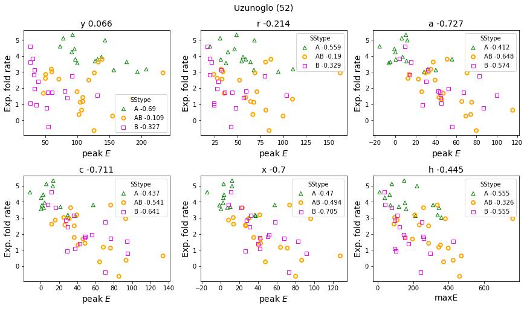

```python
# df = eval('a' + "_df")
# np.all(df.peakE.values == a_df.peakE.values) # True

fig, axes = plt.subplots(2, 3, figsize=(12, 7), constrained_layout=True)
plt.suptitle("Uzunoglo (52)", fontsize=14)
for i, ndv in enumerate(NDVs[:-1]):
    r = i//3; c = i%3; ax1 = axes[r][c]
    df = eval(ndv + "_df"); rs = eval(ndv + "_rs")
    nd.plot_peakE_by_SStype(df, ax1, rs)
    ax1.set_title(ndv + ' ' + str(np.round(rs[0], 3)) , fontsize=14)
    ax1.legend(title="SStype")

ax1 = axes[1][2]
nd.plot_maxE_by_SStype(h_df, ax1, h_rs)
ax1.set_title('h ' + str(np.round(h_rs[0], 3)), fontsize=14)
_ = ax1.legend(title="SStype")
```

```python
# Z == All
dr = pd.DataFrame({'SStype': ['Z', 'A', 'AB', 'B'],
                'y_rs': y_rs, 'y_ps': y_ps, 'r_rs': r_rs, 'r_ps': r_ps,
                'a_rs': a_rs, 'a_ps': a_ps, 'c_rs': c_rs, 'c_ps': c_ps,
                'x_rs': x_rs, 'x_ps': x_ps, 'h_rs': h_rs, 'h_ps': h_ps,}).set_index('SStype')
UZcorrs_dr = dr.join(n_dr)
```

```python
# save to file
UZcorrs_dr.to_csv("UZcorrs_dr.txt", sep=' ')
```

```python
# desire corrs with ND variants to be stronger than with 'h' or 'n',
# since generating peak Es involve more work
df = UZcorrs_dr.filter(regex='_rs').T
df.round(4)
```

| SStype | Z | A | AB | B |
| --- | --- | --- | --- | --- |
| y_rs | 0.0664 | -0.6905 | -0.1091 | -0.3274 |
| r_rs | -0.2145 | -0.5590 | -0.1903 | -0.3294 |
| a_rs | -0.7267 | -0.4121 | -0.6481 | -0.5744 |
| c_rs | -0.7106 | -0.4370 | -0.5412 | -0.6408 |
| x_rs | -0.6995 | -0.4700 | -0.4938 | -0.7052 |
| h_rs | -0.4446 | -0.5552 | -0.3260 | -0.5550 |
| n_rs | -0.4355 | -0.6721 | -0.1850 | -0.7425 |
| n12_rs | -0.4572 | -0.6842 | -0.1988 | -0.7502 |
| n23_rs | -0.4504 | -0.6807 | -0.1944 | -0.7479 |

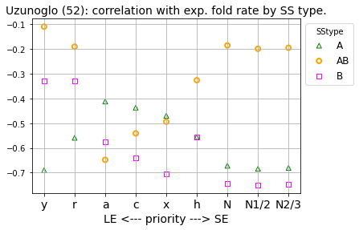

```python
# smaller (more negative) is better
Xs = NDVs[:]; Xs.extend(['N', 'N1/2', 'N2/3'])
fig, ax = plt.subplots()
ax.scatter(Xs, df.A.values, marker='^', edgecolor='green', facecolor='none', label='A')
ax.scatter(Xs, df.AB.values, edgecolor='orange', lw=2, facecolor='none', label='AB')
ax.scatter(Xs, df.B.values, marker='s', edgecolor='magenta', facecolor='none', label='B')
ax.set_xticks(Xs); ax.set_xticklabels(Xs, fontsize=14)
ax.set_xlabel("LE <--- priority ---> SE", fontsize=14)
ax.set_title("Uzunoglo (52): correlation with exp. fold rate by SS type.", fontsize=14)
ax.legend(title="SStype", fontsize=12, loc="upper left", bbox_to_anchor=(1.0, 1.0))
ax.grid()
```

- If the task at hand is simply predicting fold-rate, *N* is competitive with ND, and simpler than ND, for structurally pure SStype chains, *A* and *B*.
- ND variants are also better at modelling structurally pure chains:
  - For *A*, ND variants that "prioritize" LE over SE ('y' and 'r') do better.
  - For *B*, ND variants that "prioritize" SE over LE ('x' and 'c') do better.
- The problematic class is structurally mixed SStype chains (*AB*), which seem to thrive in the "Goldilocks region" created by ND variant 'a' which strikes a good balance between LE and SE.
- Goal is to design a ND variant that can handle all kinds of chains well.
  - An idea that presents itself is to combine the best of these ND variants.

### Problem of trying to mix peak $E$s from different ND variants

- ND energy ranges differ.

```python
alpha_df = y_df.query("SStype == 'a'")
alphabeta_df = a_df.query("SStype == 'ab'")
beta_df = x_df.query("SStype == 'b'")
yax_df = alpha_df.append(beta_df).append(alphabeta_df)
print(len(alpha_df), len(alphabeta_df), len(beta_df), len(yax_df))
yax_rs, yax_ps = nd.analyze_peakE_by_SStype(yax_df, ndv='y-a-x')
```

```
15 20 17 52
Pearson correlation with exp. fold rate: y-a-x
All: [0.1927 0.1711]
A: [-0.6905  0.0044]
AB: [-0.6481  0.002 ]
B: [-0.7052  0.0016]
```

```python
alpha_df = r_df.query("SStype == 'a'")
alphabeta_df = a_df.query("SStype == 'ab'")
beta_df = x_df.query("SStype == 'b'")
rax_df = alpha_df.append(beta_df).append(alphabeta_df)
print(len(alpha_df), len(alphabeta_df), len(beta_df), len(rax_df))
rax_rs, rax_ps = nd.analyze_peakE_by_SStype(rax_df, ndv='r-a-x')
```

```
15 20 17 52
Pearson correlation with exp. fold rate: r-a-x
All: [-0.3896  0.0043]
A: [-0.559   0.0303]
AB: [-0.6481  0.002 ]
B: [-0.7052  0.0016]
```

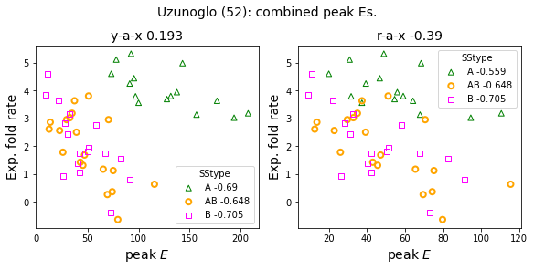

```python
fig, (ax1, ax2) = plt.subplots(1, 2, figsize=(8, 4), constrained_layout=True)
plt.suptitle("Uzunoglo (52): combined peak Es.", fontsize=14)
ax1.set_title("y-a-x " + str(np.round(yax_rs[0], 3)), fontsize=14)
nd.plot_peakE_by_SStype(yax_df, ax1, yax_rs)
ax1.legend(title="SStype")
ax2.set_title("r-a-x " + str(np.round(rax_rs[0], 3)), fontsize=14)
nd.plot_peakE_by_SStype(rax_df, ax2, rax_rs)
_ = ax2.legend(title="SStype")
```

### A simple first solution with unscaled $p_e$

- The effect of scaling on $p_e$ for longer range contacts was reported previously, and now put to use.

```python
dirn = os.path.join("UZ_ND3", "notscaled")
```

```python
peakEs, peakQs = nd.get_ndv_peakEs(dirn, UZ_PIDs, "stats", ndv='x_notscaled')
ux_df = DF.assign(peakE = peakEs)
ux_rs, ux_ps = nd.analyze_peakE_by_SStype(ux_df, ndv='ux')

peakEs, peakQs = nd.get_ndv_peakEs(dirn, UZ_PIDs, "stats", ndv='c_notscaled')
uc_df = DF.assign(peakE = peakEs)
uc_rs, uc_ps = nd.analyze_peakE_by_SStype(uc_df, ndv='uc')

peakEs, peakQs = nd.get_ndv_peakEs(dirn, UZ_PIDs, "stats", ndv='a_notscaled')
ua_df = DF.assign(peakE = peakEs)
ua_rs, ua_ps = nd.analyze_peakE_by_SStype(ua_df, ndv='ua')
```

```
Pearson correlation with exp. fold rate: ux
All: [-0.5418  0.    ]
A: [-0.5723  0.0258]
AB: [-0.3542  0.1254]
B: [-0.4549  0.0666]

Pearson correlation with exp. fold rate: uc
All: [-0.5533  0.    ]
A: [-0.5264  0.0438]
AB: [-0.4392  0.0527]
B: [-0.4379  0.0788]

Pearson correlation with exp. fold rate: ua
All: [-0.4299  0.0015]
A: [-0.2204  0.4299]
AB: [-0.3907  0.0886]
B: [-0.2014  0.4382]
```

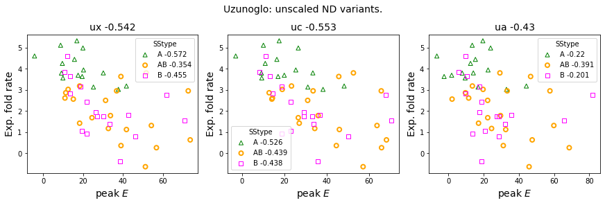

```python
fig, (ax1, ax2, ax3) = plt.subplots(1, 3, figsize=(12, 4), constrained_layout=True)
plt.suptitle("Uzunoglo: unscaled ND variants.", fontsize=14)

ax1.set_title("ux " + str(np.round(ux_rs[0], 3)), fontsize=14)
nd.plot_peakE_by_SStype(ux_df, ax1, ux_rs)
ax1.legend(title="SStype")

ax2.set_title("uc " + str(np.round(uc_rs[0], 3)), fontsize=14)
nd.plot_peakE_by_SStype(uc_df, ax2, uc_rs)
ax2.legend(title="SStype")

ax3.set_title("ua " + str(np.round(ua_rs[0], 3)), fontsize=14)
nd.plot_peakE_by_SStype(ua_df, ax3, ua_rs)
_ = ax3.legend(title="SStype")
```

```python
unscaled_dr = pd.DataFrame({'SStype': ['Z', 'A', 'AB', 'B'],
                            'ua_rs': ua_rs, 'ua_ps': ua_ps, 'uc_rs': uc_rs, 'uc_ps': uc_ps,
                            'ux_rs': ux_rs, 'ux_ps': ux_ps}).set_index('SStype')
```

```python
UZcorrs_dr = UZcorrs_dr.join(unscaled_dr)
UZcorrs_dr.to_csv("UZcorrs_dr.txt", sep=' ')
```

```python
CDF = UZcorrs_dr.filter(regex='_rs').T
CDF.round(4)
```

| SStype | Z | A | AB | B |
| --- | --- | --- | --- | --- |
| y_rs | 0.0664 | -0.6905 | -0.1091 | -0.3274 |
| r_rs | -0.2145 | -0.5590 | -0.1903 | -0.3294 |
| a_rs | -0.7267 | -0.4121 | -0.6481 | -0.5744 |
| c_rs | -0.7106 | -0.4370 | -0.5412 | -0.6408 |
| x_rs | -0.6995 | -0.4700 | -0.4938 | -0.7052 |
| h_rs | -0.4446 | -0.5552 | -0.3260 | -0.5550 |
| n_rs | -0.4355 | -0.6721 | -0.1850 | -0.7425 |
| n12_rs | -0.4572 | -0.6842 | -0.1988 | -0.7502 |
| n23_rs | -0.4504 | -0.6807 | -0.1944 | -0.7479 |
| ua_rs | -0.4299 | -0.2204 | -0.3907 | -0.2014 |
| uc_rs | -0.5533 | -0.5264 | -0.4392 | -0.4379 |
| ux_rs | -0.5418 | -0.5723 | -0.3542 | -0.4549 |

```python
CDF.A.sort_values()
```

```
y_rs     -0.690474
n12_rs   -0.684221
n23_rs   -0.680697
n_rs     -0.672115
ux_rs    -0.572340
r_rs     -0.559032
h_rs     -0.555163
uc_rs    -0.526444
x_rs     -0.470023
c_rs     -0.437038
a_rs     -0.412113
ua_rs    -0.220431
Name: A, dtype: float64
```

```python
CDF.AB.sort_values()
```

```
a_rs     -0.648068
c_rs     -0.541155
x_rs     -0.493830
uc_rs    -0.439166
ua_rs    -0.390667
ux_rs    -0.354226
h_rs     -0.325991
n12_rs   -0.198762
n23_rs   -0.194397
r_rs     -0.190254
n_rs     -0.185007
y_rs     -0.109097
Name: AB, dtype: float64
```

```python
CDF.B.sort_values()
```

```
n12_rs   -0.750195
n23_rs   -0.747886
n_rs     -0.742475
x_rs     -0.705247
c_rs     -0.640761
a_rs     -0.574378
h_rs     -0.555005
ux_rs    -0.454861
uc_rs    -0.437884
r_rs     -0.329368
y_rs     -0.327428
ua_rs    -0.201439
Name: B, dtype: float64
```

```python
# plot to compare these ND variants
Xs = ['y', 'r', 'ua', 'a', 'uc', 'c', 'ux', 'x', 'h', 'n12']
hdf = CDF.copy()
hdf = hdf.reindex([l+"_rs" for l in Xs])
hdf
```

| SStype | Z | A | AB | B |
| --- | --- | --- | --- | --- |
| y_rs | 0.066354 | -0.690474 | -0.109097 | -0.327428 |
| r_rs | -0.214498 | -0.559032 | -0.190254 | -0.329368 |
| ua_rs | -0.429877 | -0.220431 | -0.390667 | -0.201439 |
| a_rs | -0.726708 | -0.412113 | -0.648068 | -0.574378 |
| uc_rs | -0.553336 | -0.526444 | -0.439166 | -0.437884 |
| c_rs | -0.710594 | -0.437038 | -0.541155 | -0.640761 |
| ux_rs | -0.541776 | -0.572340 | -0.354226 | -0.454861 |
| x_rs | -0.699528 | -0.470023 | -0.493830 | -0.705247 |
| h_rs | -0.444587 | -0.555163 | -0.325991 | -0.555005 |
| n12_rs | -0.457243 | -0.684221 | -0.198762 | -0.750195 |

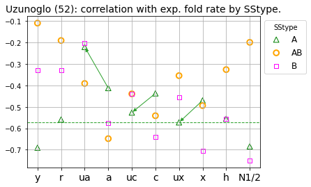

```python
# smaller (more negative) is better
NDVs = ['y', 'r', 'ua', 'a', 'uc', 'c', 'ux', 'x', 'h', 'N1/2']
fig, ax = plt.subplots()
ax.scatter(NDVs, hdf.A.values, marker='^',s=60, edgecolor='green',facecolor='none', label='A')
ax.scatter(NDVs, hdf.AB.values, edgecolor='orange', lw=2, s=60, facecolor='none', label='AB')
ax.scatter(NDVs, hdf.B.values, marker='s', edgecolor='magenta', facecolor='none', label='B')
ax.axhline(y=-0.5723, color="tab:green", lw=1, ls='--')
ax.annotate("", xy=('ux', -0.5723), xycoords='data', xytext=('x', -0.47),
        arrowprops=dict(arrowstyle='-|>', connectionstyle="arc3", color='tab:green'))
ax.annotate("", xy=('uc', -0.5264), xycoords='data', xytext=('c', -0.437),
        arrowprops=dict(arrowstyle='-|>', connectionstyle="arc3", color='tab:green'))
ax.annotate("", xy=('ua', -0.2204), xycoords='data', xytext=('a', -0.4121),
        arrowprops=dict(arrowstyle='-|>', connectionstyle="arc3", color='tab:green'))
ax.set_xticks(NDVs); ax.set_xticklabels(NDVs, fontsize=14)
ax.set_title("Uzunoglo (52): correlation with exp. fold rate by SStype.", fontsize=14)
ax.legend(title="SStype", fontsize=12, loc="upper left", bbox_to_anchor=(1.0, 1.0))
ax.grid()
```

- Unscaled $p_e$ with ND variants 'x' and 'c':
  - peak$E$ correlation with exp. fold rate strengthens for *A*, but weakens for both *B* and *AB*.
  - unscaled 'x' ('ux') corr. for *A* is competitive with 'r'.
- This is expected behavior, since scaling reduces $p_e$ for LE, and findings so far indicate that *A* will benefit but *B* will suffer from an increase in $p_e$ of LE.
- However, all correlations weaken with unscaled 'a' ('ua'). This could be the lingering of effect of restricting node selection to a local neighborhood (crony).
  - Node selection is more "explorative" with 'c' (selection is by remaining node degree over all nodes) and 'x' (uniform node selection, like 'r').

### Combine unscaled and scaled ND variants

```python
# mixed unscaled and scaled x, with a
alpha_df = ux_df.query("SStype == 'a'")
alphabeta_df = a_df.query("SStype == 'ab'")
beta_df = x_df.query("SStype == 'b'")
uxax_df = alpha_df.append(beta_df).append(alphabeta_df)
print(len(alpha_df), len(alphabeta_df), len(beta_df), len(uxax_df))
uxax_rs, uxax_ps = nd.analyze_peakE_by_SStype(uxax_df, ndv='ux-a-x')
print(nd.mjes_range(uxax_df.peakE.values))
```

```
15 20 17 52
Pearson correlation with exp. fold rate: ux-a-x
All: [-0.7666  0.    ]
A: [-0.5723  0.0258]
AB: [-0.6481  0.002 ]
B: [-0.7052  0.0016]

4.165713579469035
```

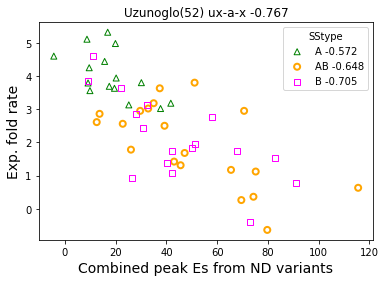

```python
fig, ax1 = plt.subplots()
ax1.set_title("Uzunoglo(52) ux-a-x " + str(np.round(uxax_rs[0], 3)))
nd.plot_peakE_by_SStype(uxax_df, ax1, uxax_rs)
ax1.set_xlabel("Combined peak Es from ND variants")
_ = ax1.legend(title="SStype")
```

- Best mixed ND-soft model found so far is 'ux-a-x':
  - achieves overall correlation of -0.7666, and correlations by SStype are all significant.
  - uses unscaled 'x' for *a* type chains (-0.5723, 0.0258).
  - uses scaled 'a' for *ab* type chains (-0.6481, 0.002).
  - uses scaled 'x' for *b* type chains (-0.7052, 0.0016).

### Kamagata dataset.

- ND results are much weaker for this dataset, which is dominated by *AB* chains.
- ND 'a' corr. is not much better than with chain length *N*, but 'a' gives insight into the folding process by suggesting an edge ordering, while *N* does not and cannot.

```python
dirname = "Kamagata"
fn = os.path.join(dirname, "K_foldtype.txt")
df = pd.read_table(fn, sep='\t')
# remove outlier '1ael' for ND results
DF = df.query("pid != '1ael'") # reserve DF for this purpose!
DF.head()
```

|  | pid | N | k_f | SStype |
| --- | --- | --- | --- | --- |
| 0 | 1pgb | 56 | 2.78 | ab |
| 1 | 2cro | 64 | 1.52 | a |
| 2 | 1cei | 85 | 2.49 | a |
| 3 | 2abd | 86 | 2.81 | a |
| 4 | 1hng | 86 | 0.78 | b |

```python
K_PIDs = DF.pid.values
print(len(K_PIDs), np.ptp(DF.k_f.values), DF.N.max())
K_SStypes = DF.SStype.values
```

```
20 4.55 175
```

```python
df = nd.count_HSTs("Kamagata", K_PIDs, K_SStypes)
df.sample(5)
```

|  | H | S | T | hsr | SStype |
| --- | --- | --- | --- | --- | --- |
| 1adw | 23 | 45 | 55 | 0.511111 | ab |
| 1bni | 24 | 25 | 59 | 0.960000 | ab |
| 2a5e | 66 | 0 | 90 | 66.000000 | a |
| 1bta | 37 | 16 | 36 | 2.312500 | ab |
| 2rn2 | 55 | 47 | 53 | 1.170213 | ab |

```python
# nH > 3, nS < 10
da = df.query("SStype == 'a'")
print(len(da))
da
```

```
5
```

|  | H | S | T | hsr | SStype |
| --- | --- | --- | --- | --- | --- |
| 2cro | 40 | 0 | 24 | 40.0 | a |
| 1cei | 49 | 2 | 34 | 24.5 | a |
| 2abd | 52 | 0 | 34 | 52.0 | a |
| 1dwr | 115 | 0 | 37 | 115.0 | a |
| 2a5e | 66 | 0 | 90 | 66.0 | a |

```python
# nH < 3, nS > 10
db = df.query("SStype == 'b'")
print(len(db))
db
```

```
3
```

|  | H | S | T | hsr | SStype |
| --- | --- | --- | --- | --- | --- |
| 1hng | 0 | 41 | 45 | 0.0 | b |
| 1tit | 0 | 33 | 56 | 0.0 | b |
| 1ttg | 0 | 43 | 51 | 0.0 | b |

```python
# nH > 3, nS > 10
dab = df.query("SStype == 'ab'")
print(len(dab))
dab
```

```
12
```

|  | H | S | T | hsr | SStype |
| --- | --- | --- | --- | --- | --- |
| 1pgb | 14 | 24 | 18 | 0.583333 | ab |
| 1gxt | 21 | 36 | 31 | 0.583333 | ab |
| 1bta | 37 | 16 | 36 | 2.312500 | ab |
| 1bni | 24 | 25 | 59 | 0.960000 | ab |
| 1adw | 23 | 45 | 55 | 0.511111 | ab |
| 3chy | 58 | 22 | 48 | 2.636364 | ab |
| 1joo | 35 | 37 | 77 | 0.945946 | ab |
| 1i1b | 8 | 72 | 71 | 0.111111 | ab |
| 2rn2 | 55 | 47 | 53 | 1.170213 | ab |
| 1ra9 | 40 | 50 | 69 | 0.800000 | ab |
| 1l63 | 107 | 15 | 40 | 7.133333 | ab |
| 1php | 69 | 27 | 79 | 2.555556 | ab |

```
Pearson correlation with exp. fold rate: chain-length N 1
All: [-0.5623  0.0099]
A: [-0.5364  0.3513]
AB: [-0.5564  0.0603]
B: [0.996 0.057]

Pearson correlation with exp. fold rate: chain-length N 0.5
All: [-0.5719  0.0084]
A: [-0.4994  0.3917]
AB: [-0.5823  0.047 ]
B: [0.9965 0.0533]

Pearson correlation with exp. fold rate: chain-length N 0.6666666666666666
All: [-0.5691  0.0088]
A: [-0.5124  0.3774]
AB: [-0.5741  0.0509]
B: [0.9963 0.0545]
```

| SStype | n_rs | n_ps | n12_rs | n12_ps | n23_rs | n23_ps |
| --- | --- | --- | --- | --- | --- | --- |
| Z | -0.562293 | 0.009862 | -0.571902 | 0.008422 | -0.569059 | 0.008829 |
| A | -0.536434 | 0.351332 | -0.499379 | 0.391687 | -0.512422 | 0.377363 |
| AB | -0.556397 | 0.060275 | -0.582329 | 0.046954 | -0.574065 | 0.050948 |
| B | 0.995988 | 0.057047 | 0.996501 | 0.053271 | 0.996334 | 0.054532 |

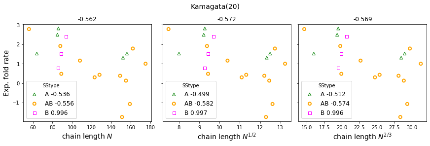

```python
n_dr = nd.frate_corrs_with_N_by_SStype(DF, "Kamagata(20)")
n_dr
```

### ND-hard (ndh)

```python
dirn = os.path.join("K_NDH", "hard")
pid = "2abd"
fn = os.path.join(dirn, pid + "_bsd_hstats_h.out")
dh = pd.read_table(fn, sep=' ')
dh.head()
```

|  | bid | fe | fsc | sc_mje | num_sc | num_scle | num_nnsc | num_nnscle |
| --- | --- | --- | --- | --- | --- | --- | --- | --- |
| 0 | 2 | 0.109661 | 0.000000 | 0.00 | 0 | 0 | 0 | 0 |
| 1 | 3 | 0.210183 | 0.476821 | 24.92 | 72 | 0 | 83 | 0 |
| 2 | 4 | 0.297650 | 0.768212 | -46.39 | 116 | 0 | 107 | 0 |
| 3 | 5 | 0.379896 | 0.814570 | 81.04 | 123 | 0 | 161 | 0 |
| 4 | 6 | 0.447781 | 0.821192 | 206.50 | 124 | 0 | 208 | 0 |

```python
maxEs, argmaxEs, maxE_sds = nd.get_ndh_maxEs(dirn, K_PIDs)
h_df = DF.assign(maxE=maxEs, maxE_sd=maxE_sds)
h_df.head()
```

|  | pid | N | k_f | SStype | maxE | maxE_sd |
| --- | --- | --- | --- | --- | --- | --- |
| 0 | 1pgb | 56 | 2.78 | ab | 91.88 | 11 |
| 1 | 2cro | 64 | 1.52 | a | 49.89 | 13 |
| 2 | 1cei | 85 | 2.49 | a | 154.90 | 10 |
| 3 | 2abd | 86 | 2.81 | a | 359.52 | 12 |
| 4 | 1hng | 86 | 0.78 | b | 161.08 | 17 |

```
maxE_sds: 20.65 9.166730462297942 10 38
maxE Pearson corr. with exp. fold rate: (-0.350480953363002, 0.12977119399473655)
```

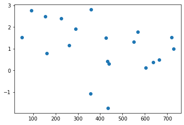

```python
print("maxE_sds:", np.mean(maxE_sds), np.std(maxE_sds, ddof=1),
      np.min(maxE_sds), np.max(maxE_sds))
# correlation maxEs with exp. fold rate
print("maxE Pearson corr. with exp. fold rate:", pearsonr(maxEs, DF.k_f.values))
# outlier?
_ = plt.scatter(maxEs, DF.k_f.values)
```

```python
h_rs, h_ps = nd.analyze_maxE_by_SStype(h_df)
```

```
maxE_sd mean stdev
All: [20.65    9.1667]
A: [17.6     9.7622]
AB: [22.9167  9.6244]
B: [16.6667  4.5092]

Pearson correlation with exp. fold rate: maxE
All: [-0.3505  0.1298]
A: [-0.3426  0.5725]
AB: [-0.3071  0.3316]
B: [0.1789 0.8855]
```

- K maxE_sd is much larger than UZ.
- All corrs. are insignificant.

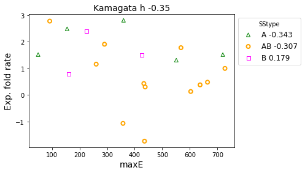

```python
fig, ax1 = plt.subplots()
ax1.set_title("Kamagata h " + str(np.round(h_rs[0] ,3)), fontsize=14)
nd.plot_maxE_by_SStype(h_df, ax1, h_rs)
_ = ax1.legend(title="SStype", fontsize=12, loc="upper left", bbox_to_anchor=(1.0, 1.0))
```

### ND variants: craxy

```python
dirn = os.path.join("K_ND3", "edv_a")
```

```python
peakEs, peakQs = nd.get_ndv_peakEs(dirn, K_PIDs, "stats", ndv='a')
a_df = DF.assign(peakE = peakEs)
a_rs, a_ps = nd.analyze_peakE_by_SStype(a_df, 'a')

peakEs, peakQs = nd.get_ndv_peakEs(dirn, K_PIDs, "stats", ndv='c')
c_df = DF.assign(peakE = peakEs)
c_rs, c_ps = nd.analyze_peakE_by_SStype(c_df, 'c')

peakEs, peakQs = nd.get_ndv_peakEs(dirn, K_PIDs, "stats", ndv='x')
x_df = DF.assign(peakE = peakEs)
x_rs, x_ps = nd.analyze_peakE_by_SStype(x_df, 'x')

peakEs, peakQs = nd.get_ndv_peakEs(dirn, K_PIDs, "stats", ndv='r')
r_df = DF.assign(peakE = peakEs)
r_rs, r_ps = nd.analyze_peakE_by_SStype(r_df, 'r')

peakEs, peakQs = nd.get_ndv_peakEs(dirn, K_PIDs, "stats", ndv='y')
y_df = DF.assign(peakE = peakEs)
y_rs, y_ps = nd.analyze_peakE_by_SStype(y_df, 'y')
```

```
Pearson correlation with exp. fold rate: a
All: [-0.5618  0.0099]
A: [-0.0612  0.9221]
AB: [-0.6306  0.0279]
B: [-0.0617  0.9607]

Pearson correlation with exp. fold rate: c
All: [-0.5525  0.0115]
A: [-0.2831  0.6444]
AB: [-0.522   0.0817]
B: [-0.0771  0.9509]

Pearson correlation with exp. fold rate: x
All: [-0.5543  0.0112]
A: [-0.1763  0.7767]
AB: [-0.5111  0.0894]
B: [-0.0014  0.9991]

Pearson correlation with exp. fold rate: r
All: [-0.278   0.2354]
A: [-0.3437  0.5712]
AB: [-0.3263  0.3005]
B: [0.0228 0.9855]

Pearson correlation with exp. fold rate: y
All: [-0.0909  0.7031]
A: [-0.4993  0.3918]
AB: [-0.0982  0.7614]
B: [0.0273 0.9826]
```

```python
dirn = os.path.join("K_ND3", "notscaled")

peakEs, peakQs = nd.get_ndv_peakEs(dirn, K_PIDs, "stats", ndv='a_notscaled')
ua_df = DF.assign(peakE = peakEs)
ua_rs, ua_ps = nd.analyze_peakE_by_SStype(ua_df, 'ua')

peakEs, peakQs = nd.get_ndv_peakEs(dirn, K_PIDs, "stats", ndv='c_notscaled')
uc_df = DF.assign(peakE = peakEs)
uc_rs, uc_ps = nd.analyze_peakE_by_SStype(uc_df, 'uc')

peakEs, peakQs = nd.get_ndv_peakEs(dirn, K_PIDs, "stats", ndv='x_notscaled')
ux_df = DF.assign(peakE = peakEs)
ux_rs, ux_ps = nd.analyze_peakE_by_SStype(ux_df, 'ux')
```

```
Pearson correlation with exp. fold rate: ua
All: [-0.3502  0.1301]
A: [0.0087 0.989 ]
AB: [-0.4751  0.1186]
B: [-0.0931  0.9407]

Pearson correlation with exp. fold rate: uc
All: [-0.4824  0.0312]
A: [-0.2302  0.7095]
AB: [-0.6005  0.039 ]
B: [-0.0823  0.9475]

Pearson correlation with exp. fold rate: ux
All: [-0.4338  0.056 ]
A: [-0.2483  0.6871]
AB: [-0.4988  0.0988]
B: [-0.0094  0.994 ]
```

### Summary of results for analysis of K by SS type:

```python
Kcorrs_dr = pd.DataFrame({'SStype': ['Z', 'A', 'AB', 'B'],
                'y_rs': y_rs, 'y_ps': y_ps, 'r_rs': r_rs, 'r_ps': r_ps,
                'ua_rs': ua_rs, 'ua_ps': ua_ps, 'a_rs': a_rs, 'a_ps': a_ps,
                'uc_rs': uc_rs, 'uc_ps': uc_ps, 'c_rs': c_rs, 'c_ps': c_ps,
                'ux_rs': ux_rs, 'ux_ps': ux_ps, 'x_rs': x_rs, 'x_ps': x_ps,
                'h_rs': h_rs, 'h_ps': h_ps, }).set_index('SStype')
Kcorrs_dr = Kcorrs_dr.join(n_dr)
```

```python
Kcorrs_dr.to_csv("KCorrs_dr.txt", sep=' ')
```

```python
CDF = Kcorrs_dr.filter(regex="_rs").T
CDF.round(4)
```

| SStype | Z | A | AB | B |
| --- | --- | --- | --- | --- |
| y_rs | -0.0909 | -0.4993 | -0.0982 | 0.0273 |
| r_rs | -0.2780 | -0.3437 | -0.3263 | 0.0228 |
| ua_rs | -0.3502 | 0.0087 | -0.4751 | -0.0931 |
| a_rs | -0.5618 | -0.0612 | -0.6306 | -0.0617 |
| uc_rs | -0.4824 | -0.2302 | -0.6005 | -0.0823 |
| c_rs | -0.5525 | -0.2831 | -0.5220 | -0.0771 |
| ux_rs | -0.4338 | -0.2483 | -0.4988 | -0.0094 |
| x_rs | -0.5543 | -0.1763 | -0.5111 | -0.0014 |
| h_rs | -0.3505 | -0.3426 | -0.3071 | 0.1789 |
| n_rs | -0.5623 | -0.5364 | -0.5564 | 0.9960 |
| n12_rs | -0.5719 | -0.4994 | -0.5823 | 0.9965 |
| n23_rs | -0.5691 | -0.5124 | -0.5741 | 0.9963 |

```python
CDF.Z.sort_values()
```

```
n12_rs   -0.571902
n23_rs   -0.569059
n_rs     -0.562293
a_rs     -0.561783
x_rs     -0.554254
c_rs     -0.552456
uc_rs    -0.482393
ux_rs    -0.433768
h_rs     -0.350481
ua_rs    -0.350213
r_rs     -0.277979
y_rs     -0.090915
Name: Z, dtype: float64
```

```python
CDF.A.sort_values()
```

```
n_rs     -0.536434
n23_rs   -0.512422
n12_rs   -0.499379
y_rs     -0.499269
r_rs     -0.343654
h_rs     -0.342557
c_rs     -0.283099
ux_rs    -0.248295
uc_rs    -0.230229
x_rs     -0.176308
a_rs     -0.061210
ua_rs     0.008665
Name: A, dtype: float64
```

```python
CDF.AB.sort_values()
```

```
a_rs     -0.630587
uc_rs    -0.600451
n12_rs   -0.582329
n23_rs   -0.574065
n_rs     -0.556397
c_rs     -0.521978
x_rs     -0.511124
ux_rs    -0.498820
ua_rs    -0.475065
r_rs     -0.326349
h_rs     -0.307109
y_rs     -0.098194
Name: AB, dtype: float64
```

```python
CDF.B.sort_values()
```

```
ua_rs    -0.093051
uc_rs    -0.082309
c_rs     -0.077122
a_rs     -0.061738
ux_rs    -0.009396
x_rs     -0.001361
r_rs      0.022767
y_rs      0.027334
h_rs      0.178924
n_rs      0.995988
n23_rs    0.996334
n12_rs    0.996501
Name: B, dtype: float64
```

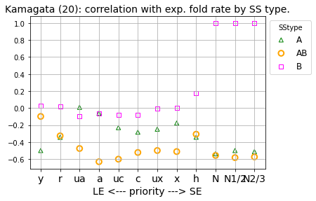

```python
NDVs = ['y', 'r', 'ua', 'a', 'uc', 'c', 'ux', 'x', 'h', 'N', 'N1/2', 'N2/3']
# smaller (more negative) is better
fig, ax = plt.subplots()
ax.scatter(NDVs, CDF.A.values, marker='^', edgecolor='green', facecolor='none', label='A')
ax.scatter(NDVs, CDF.AB.values, edgecolor='orange', lw=2, s=60, facecolor='none', label='AB')
ax.scatter(NDVs, CDF.B.values, marker='s', edgecolor='magenta', facecolor='none', label='B')
ax.set_xticks(NDVs); ax.set_xticklabels(NDVs, fontsize=14)
ax.set_xlabel("LE <--- priority ---> SE", fontsize=14)
ax.set_title("Kamagata (20): correlation with exp. fold rate by SS type.", fontsize=14)
ax.legend(title="SStype", fontsize=12, loc="upper left", bbox_to_anchor=(1.0, 1.0))
ax.grid()
```

```python
dp = Kcorrs_dr.filter(regex="_ps").T
db = dp.apply(lambda x: x < 0.05)
db
```

| SStype | Z | A | AB | B |
| --- | --- | --- | --- | --- |
| y_ps | False | False | False | False |
| r_ps | False | False | False | False |
| ua_ps | False | False | False | False |
| a_ps | True | False | True | False |
| uc_ps | True | False | True | False |
| c_ps | True | False | False | False |
| ux_ps | False | False | False | False |
| x_ps | True | False | False | False |
| h_ps | False | False | False | False |
| n_ps | True | False | False | False |
| n12_ps | True | False | True | False |
| n23_ps | True | False | False | False |

- As observed previously with UZ, 'y' and 'r' perform better (but insig.) for A chains, and 'a' produces strongest (and sig.) corr. for AB. However, no ND variant produces a sig. corr. for *B*.
- Except for ND variants 'a' an 'uc' on AB chains, the corrs. by chain SStype are insignificant (p-value < 0.05).
- Data problem: *A* and *B* classes have fewer than 10 chains each.

```python
# combine y-a-ua
alpha_df = y_df.query("SStype == 'a'")
alphabeta_df = a_df.query("SStype == 'ab'")
beta_df = ua_df.query("SStype == 'b'")
yaua_df = alpha_df.append(beta_df).append(alphabeta_df)
print(len(alpha_df), len(alphabeta_df), len(beta_df), len(yaua_df))
yaua_rs, yaua_ps = nd.analyze_peakE_by_SStype(yaua_df, ndv='y-a-ua')
print(nd.mjes_range(yaua_df.peakE.values))
```

```
5 12 3 20
Pearson correlation with exp. fold rate: y-a-ua
All: [0.1176 0.6215]
A: [-0.4993  0.3918]
AB: [-0.6306  0.0279]
B: [-0.0931  0.9407]

3.5322812572893088
```

```python
# combine ux-a-ua
alpha_df = ux_df.query("SStype == 'a'")
alphabeta_df = a_df.query("SStype == 'ab'")
beta_df = ua_df.query("SStype == 'b'")
uxaua_df = alpha_df.append(beta_df).append(alphabeta_df)
print(len(alpha_df), len(alphabeta_df), len(beta_df), len(uxaua_df))
uxaua_rs, uxaua_ps = nd.analyze_peakE_by_SStype(uxaua_df, ndv='ux-a-ua')
print(nd.mjes_range(uxaua_df.peakE.values))
```

```
5 12 3 20
Pearson correlation with exp. fold rate: ux-a-ua
All: [-0.5784  0.0076]
A: [-0.2483  0.6871]
AB: [-0.6306  0.0279]
B: [-0.0931  0.9407]

3.0378335189840704
```

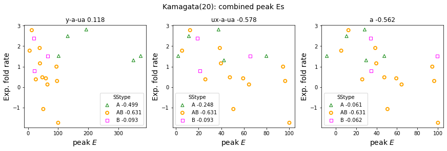

```python
fig, (ax1, ax2, ax3) = plt.subplots(1, 3, figsize=(12, 4), constrained_layout=True)
plt.suptitle("Kamagata(20): combined peak Es", fontsize=14)

ax1.set_title("y-a-ua " + str(np.round(yaua_rs[0], 3)))
nd.plot_peakE_by_SStype(yaua_df, ax1, yaua_rs)
ax1.legend(title="SStype")

ax2.set_title("ux-a-ua " + str(np.round(uxaua_rs[0], 3)))
nd.plot_peakE_by_SStype(uxaua_df, ax2, uxaua_rs)
ax2.legend(title="SStype")

ax3.set_title("a " + str(np.round(a_rs[0], 3)))
nd.plot_peakE_by_SStype(a_df, ax3, a_rs)
_ = ax3.legend(title="SStype")
```

## End of notebook

SKLC January 2021